# 1. Datensatz

### Cleaning-Process-Reihenfolge:

1. Daten als “data” Laden. > 146.000 Beobachtungen
2. Spalten “p_aaer” und “new_p_aaer” löschen, weil sie fast nur aus NaN bestehen. Restliche Var. haben max. ~10% NaN-Werte.
3. Alle Zeilen mit NaN-Werten löschen 116.478 Beobachtungen bleiben übrig.
4. all_data bilden: Besteht nur aus 14 + 28 + 2 Vars (ratios, raw, misstate & fyear)
5. all_data via Jahreszahl normalisieren. fyear danach löschen
6. raw_data (28 + 1 Vars) und ratio_data (14 + 1 Vars) aus all_data bilden
7. Explorative Datenanalyse

#### 1.1 Daten als “data” Laden

```r
data <- import("data/uscecchini28.csv")
```

#### 1.2 Spalten “p_aaer” und “new_p_aaer” löschen

```r
data <- data[,-match(c("p_aaer", "new_p_aaer"), names(data))]
```

#### 1.3 Alle Zeilen mit NaN-Werten löschen

```r
data <- data[complete.cases(data),]
```

#### 1.4 all_data bilden: Besteht nur aus 14 + 28 + 2 Vars

```r
all_names <- c("fyear", "misstate", "act", "ap", "at", "ceq", "che",
               "cogs", "csho", "dlc", "dltis", "dltt", "dp", "ib",
               "invt", "ivao", "ivst", "lct", "lt", "ni", "ppegt",
               "pstk", "re", "rect", "sale", "sstk", "txp", "txt",
               "xint", "prcc_f", "dch_wc", "ch_rsst", "dch_rec",
               "dch_inv", "soft_assets", "dpi", "ch_cs", "ch_cm",
               "ch_roa", "ch_fcf", "reoa", "EBIT", "issue", "bm")
all_data <- data[, match(all_names, names(data))]
```

#### 1.5 all_data via Jahreszahl normalisieren. fyear danach droppen

```r
# Funktion schreiben
normalize <- function(x){
  return((x - min(x)) / (max(x) - min(x)))
}
# Funktion anwenden
for (year in unique(all_data$fyear)){
  for (col in names(all_data)){
    all_data[data$fyear == year, col] <- normalize(
      all_data[data$fyear == year, col]
      )
  }
}
all_data <- all_data[, -1]
```

#### 1.6 raw_data (28 + 1 Vars) und ratio_data (14 + 1 Vars) aus all_data bilden

```r
raw_names <- c("misstate", "act", "ap", "at", "ceq", "che", "cogs",
               "csho", "dlc", "dltis", "dltt", "dp", "ib", "invt",
               "ivao", "ivst", "lct", "lt", "ni", "ppegt", "pstk",
               "re", "rect", "sale", "sstk", "txp", "txt", "xint",
               "prcc_f")

ratio_names <- c("misstate", "dch_wc", "ch_rsst", "dch_rec",
                 "dch_inv", "soft_assets", "dpi", "ch_cs", "ch_cm",
                 "ch_roa", "ch_fcf", "reoa", "EBIT", "issue", "bm")

raw_data <- all_data[, match(raw_names, names(all_data))]
ratio_data <- all_data[, match(ratio_names, names(all_data))]
```

#### 1.7 Explorative Datenanlyse

Zunächst wird ergründet, wie viele Betrugsfälle anteilig im Datensatz vorliegen.

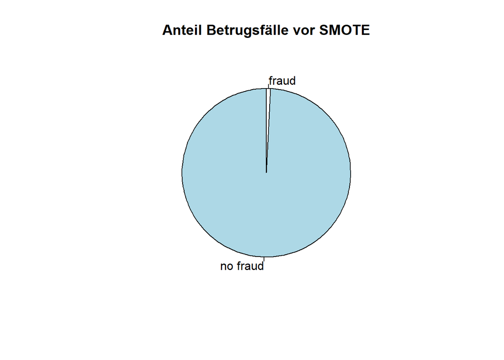

```r
# Pie chart missstate

labels <- c("fraud", "no fraud")
fraud <- sum(all_data$misstate)
no_fraud <- nrow(all_data) - sum(all_data$misstate)
fraud_smote <- no_fraud
pie(c(fraud, no_fraud), labels = labels, main="Anteil Betrugsfälle vor SMOTE", init.angle = 90, clockwise = T)
```

Anschließend ist von Interesse, ob jährlich etwa gleich viele Jahresabschlüsse untersucht wurden und ob etwa gleich viele Betrugsfälle in jedem Jahr gefunden wurden.

```r
counts <- table(data$fyear)
counts_misstate <- table(data$misstate, data$fyear)
counts_misstate_rel <- round(counts_misstate[2,] / (counts_misstate[1,] +counts_misstate[2,]), 4)

highchart() %>%
  hc_yAxis_multiples(
    list(lineWidth = 3, lineColor='grey', title=list(text="Anzahl Berichte")),
    list(lineWidth = 3, lineColor="black", title=list(text="Anteil Betrugsfälle"))
  ) %>%
  hc_add_series(data = counts, color='grey', type = "column") %>%
  hc_add_series(data = as.table(counts_misstate_rel), color='black', type = "column", yAxis = 1) %>%
  hc_xAxis(categories = unique(data$fyear), title = list(text = "Jahre"))
```

[interactive chart not shown]

Weiterhin ist die Relevanz der Normalisierung für jedes einzelne Jahr im Cleaning-Prozess zu belegen. Dafür werden hier exemplarische monetäre Variablen aufgeführt.

```r
#sales
placeholder_mean_sales <- numeric(length(unique(data$fyear)))
counter = 0
for (i in unique(data$fyear)){
  counter = counter + 1
  placeholder_mean_sales[counter] <- mean(data[data$fyear == i,]$sale)
}
names(placeholder_mean_sales) <- unique(data$fyear)

# cogs
placeholder_mean_cogs <- numeric(length(unique(data$fyear)))
counter = 0
for (i in unique(data$fyear)){
  counter = counter + 1
  placeholder_mean_cogs[counter] <- mean(data[data$fyear == i,]$cogs)
}
names(placeholder_mean_cogs) <- unique(data$fyear)

# at (assets total)
placeholder_mean_at <- numeric(length(unique(data$fyear)))
counter = 0
for (i in unique(data$fyear)){
  counter = counter + 1
  placeholder_mean_at[counter] <- mean(data[data$fyear == i,]$at)
}
names(placeholder_mean_at) <- unique(data$fyear)

highchart() %>%
  hc_yAxis_multiples(
    list(lineWidth = 3, lineColor='black', title=list(text="Durchschnitt sales")),
    list(lineWidth = 3, lineColor="grey", title=list(text="Durchschnitt cogs")),
    list(lineWidth = 3, lineColor="silver", title=list(text="Durchschnitt total Assets"))
  ) %>%
  hc_add_series(data = as.table(placeholder_mean_sales), color='black', type = "column") %>%
  hc_add_series(data = as.table(placeholder_mean_cogs), color='grey', type = "column", yAxis = 1) %>%
  hc_add_series(data = as.table(placeholder_mean_at), color='silver', type = "column", yAxis = 2) %>%
  hc_xAxis(categories = unique(data$fyear), title = list(text = "Jahre"))
```

[interactive chart not shown]

# 2. Methoden

Aufbau:

1. evaluate-Funktion bilden. Metriken: Sensistivity, Precision, F1, F2, F.5, AUC.
2. train_test_split_smote-Funktion bilden. Bildet Trainnigs- und Testdatensätze. Oversamplet Trainingsdaten vía SMOTE.
3. LogReg mit allen Daten. Ablauf:
   1. train_test_split_smote anwenden
   2. Training des Modells
   3. Vorhersage der Testdaten (in y_pred speichern)
   4. evaluate-Funktion anwenden
4. LogReg mit Rohdaten
   1. wie 3.
5. LogReg mit Ratios
   1. wie 3.
6. summary() für logit_all_data -> Parameter-Signifikanz
7. Neuronales Netz mit allen Daten
8. Neuronales Netz mit Rohdaten
9. Neuronales Netz mit Ratios

#### 2.1 evaluate-Funktion bilden

```r
evaluate <- function(test, pred, border = 0.5){

  pred_round <- ifelse(pred >= border, 1, 0)
  confusion <- table(test, pred_round)
  TN <- confusion[1,1]
  TP <- confusion[2,2]
  FP <- confusion[1,2]
  FN <- confusion[2,1]

  total_acc <- numeric(2)
  total_acc[1] <- NaN
  total_acc[2] <- round((TN + TP) / sum(confusion),4)

  prec <- numeric(2)
  prec[1] <- NaN
  prec[2] <- round(TP / (TP + FP),4)

  sens <- numeric(2)
  sens[1] <- NaN
  sens[2] <- round(TP / (TP + FN),4)

  F1 <- numeric(2)
  F1[1] <- NaN
  F1[2] <- round(2*(prec[2]*sens[2])/(prec[2] + sens[2]), 4)

  F.score <- function(beta, p = prec[2], s = sens[2]){
    round((1 + beta^2)*(p*s)/(beta^2*p + s),4)
  }

  F2 <- numeric(2)
  F2[1] <- NaN
  F2[2] <- F.score(2)

  F.5 <- numeric(2)
  F.5[1] <- NaN
  F.5[2] <- F.score(0.5)

  ROCit_obj <- rocit(score=pred,class=test)
  AUC <- numeric(2)
  AUC[1] <- NaN
  AUC[2] <- round(ROCit_obj$AUC, 4)
  plot(ROCit_obj)

  return(cbind(confusion, total_acc, prec, sens, F1, F2, F.5, AUC))
}
```

#### 2.2 train_test_split_smote bilden

```r
train_test_split_smote<- function(data, y_col, frac = 0.7, seed = 42,
                                  k = 5){
  set.seed(seed)

  smp_size <- floor(frac * nrow(data))
  train_ind <- sample(seq_len(nrow(data)), size = smp_size)

  X_smote <- data[train_ind, -match(y_col, names(data))]
  y_smote <- data[train_ind, match(y_col, names(data))]

  true_frac <- sum(y_smote) / length(y_smote)

  train_smote_object <- SMOTE(X_smote, y_smote, K = 5,
                              dup_size = 1 / true_frac)$data

  X_train <- train_smote_object[,-match('class',
                                        names(train_smote_object))]
  y_train <- as.numeric(train_smote_object[,
                        match('class', names(train_smote_object))])

  X_test <- data[-train_ind, -match(y_col, names(data))]
  y_test <- data[-train_ind, match(y_col, names(data))]

  return(list(X_train = X_train, X_test = X_test, y_train = y_train,
              y_test = y_test))
}
```

#### 2.3 Modell mit allen Daten bilden und evaluieren

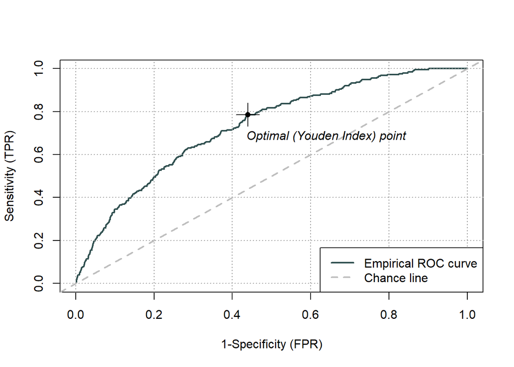

```
##       0     1 total_acc   prec   sens     F1     F2    F.5    AUC
## 0 24068 10624       NaN    NaN    NaN    NaN    NaN    NaN    NaN
## 1    91   161    0.6934 0.0149 0.6389 0.0291 0.0681 0.0185 0.7302
```

```r
splitted_data <- train_test_split_smote(data = all_data,
                                    y_col = 'misstate', frac = 0.7)

X_train <- splitted_data$X_train
X_test <- splitted_data$X_test
y_train <- splitted_data$y_train
y_test <- splitted_data$y_test

train <- X_train
train$misstate <- y_train

logit_all_data <- glm(misstate ~., data = train,
                      family = "binomial")
y_pred_logit_all_data <- predict.glm(logit_all_data,
                                     X_test, type = "response" )

evaluate(y_test, y_pred_logit_all_data)
```

#### 2.4 Modell mit Rohdaten bilden und evaluieren

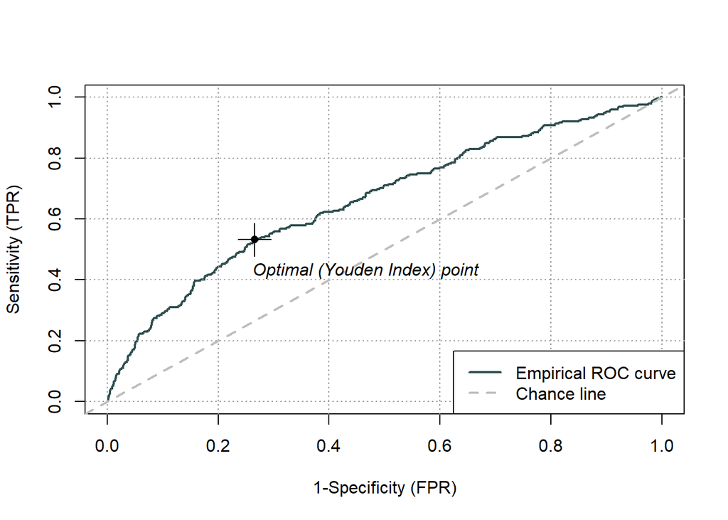

```
##       0     1 total_acc   prec   sens     F1    F2    F.5   AUC
## 0 24616 10076       NaN    NaN    NaN    NaN   NaN    NaN   NaN
## 1   115   137    0.7084 0.0134 0.5437 0.0262 0.061 0.0166 0.663
```

```r
splitted_data <- train_test_split_smote(data = raw_data,
                                    y_col = 'misstate', frac = 0.7)
X_train <- splitted_data$X_train
X_test <- splitted_data$X_test
y_train <- splitted_data$y_train
y_test <- splitted_data$y_test

train <- X_train
train$misstate <- y_train

logit_raw_data <- glm(misstate ~., data = train,
                      family = "binomial")
y_pred_logit_raw_data <- predict.glm(logit_raw_data, X_test,
                                     type = "response" )

evaluate(y_test, y_pred_logit_raw_data)
```

#### 2.5 Modell mit Ratio-Daten bilden und evaluieren

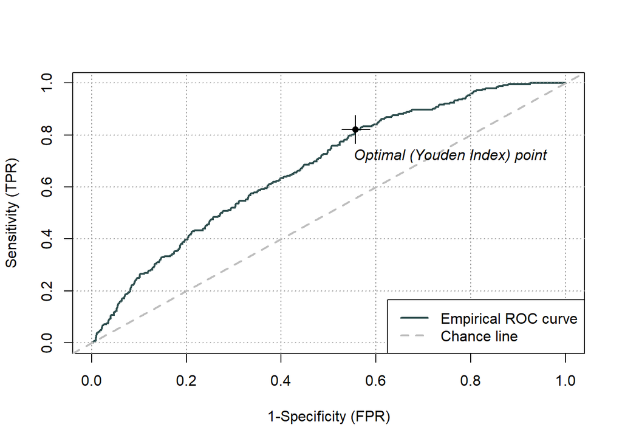

```
##       0     1 total_acc   prec   sens    F1     F2    F.5   AUC
## 0 20526 14166       NaN    NaN    NaN   NaN    NaN    NaN   NaN
## 1    91   161     0.592 0.0112 0.6389 0.022 0.0523 0.0139 0.676
```

```r
splitted_data <- train_test_split_smote(data = ratio_data,
                                    y_col = 'misstate', frac = 0.7)

X_train <- splitted_data$X_train
X_test <- splitted_data$X_test
y_train <- splitted_data$y_train
y_test <- splitted_data$y_test

train <- X_train
train$misstate <- y_train

logit_ratio_data <- glm(misstate ~., data = train,
                        family = "binomial")
y_pred_logit_ratio_data <- predict.glm(logit_ratio_data, X_test,
                                       type = "response" )

evaluate(y_test, y_pred_logit_ratio_data)
```

#### 2.6 summary() für logit_all_data

```r
summary(logit_all_data)
```

```
##
## Call:
## glm(formula = misstate ~ ., family = "binomial", data = train)
##
## Deviance Residuals:
##     Min       1Q   Median       3Q      Max
## -5.5406  -0.9641   0.1000   0.9745   5.5802
##
## Coefficients:
##              Estimate Std. Error z value Pr(>|z|)
## (Intercept) -23.75983    0.50318 -47.219  < 2e-16 ***
## act          11.12570    1.41279   7.875 3.41e-15 ***
## ap            1.98894    0.49944   3.982 6.82e-05 ***
## at           10.80001    0.82025  13.167  < 2e-16 ***
## ceq          -5.65817    0.16604 -34.078  < 2e-16 ***
## che          -3.62274    0.73212  -4.948 7.49e-07 ***
## cogs         29.99856    1.55593  19.280  < 2e-16 ***
## csho          6.41974    0.27687  23.187  < 2e-16 ***
## dlc         -12.09188    0.76046 -15.901  < 2e-16 ***
## dltis        -2.55895    0.39298  -6.512 7.43e-11 ***
## dltt         17.01835    0.72114  23.599  < 2e-16 ***
## dp           -6.59251    0.65110 -10.125  < 2e-16 ***
## ib           -0.24714    0.13140  -1.881  0.06000 .
## invt         -3.59020    0.53125  -6.758 1.40e-11 ***
## ivao          1.37159    0.43429   3.158  0.00159 **
## ivst         -2.32630    0.48566  -4.790 1.67e-06 ***
## lct          18.48910    1.38337  13.365  < 2e-16 ***
## lt          -35.46112    1.37644 -25.763  < 2e-16 ***
## ni            1.39985    0.12153  11.518  < 2e-16 ***
## ppegt        -6.34845    0.65147  -9.745  < 2e-16 ***
## pstk         -7.67877    0.35223 -21.800  < 2e-16 ***
## re            4.27251    0.05994  71.281  < 2e-16 ***
## rect          2.51693    0.80673   3.120  0.00181 **
## sale        -35.36934    1.76975 -19.986  < 2e-16 ***
## sstk          1.57673    0.23121   6.819 9.15e-12 ***
## txp          -3.70640    0.36741 -10.088  < 2e-16 ***
## txt          -0.55736    0.06326  -8.811  < 2e-16 ***
## xint          6.73976    0.38732  17.401  < 2e-16 ***
## prcc_f       12.19458    0.26323  46.327  < 2e-16 ***
## dch_wc       -1.97133    0.12683 -15.543  < 2e-16 ***
```

[output cut: 8 more lines]

```
## ch_fcf        1.91612    0.19656   9.748  < 2e-16 ***
## reoa         22.60563    0.59876  37.754  < 2e-16 ***
## EBIT         -3.30312    0.20996 -15.732  < 2e-16 ***
## issue         0.66310    0.02341  28.324  < 2e-16 ***
## bm           -0.39105    0.08582  -4.557 5.19e-06 ***
## ---
## Signif. codes:  0 '***' 0.001 '**' 0.01 '*' 0.05 '.' 0.1 ' ' 1
##
## (Dispersion parameter for binomial family taken to be 1)
##
##     Null deviance: 225660  on 162783  degrees of freedom
## Residual deviance: 184472  on 162741  degrees of freedom
## AIC: 184558
##
## Number of Fisher Scoring iterations: 7
```